# Obama Online

sundar pradeep

May 8, 2015

[figure not shown]

#### Synopsis:

The objective of this project is to collect available social / public information about President Obama and present using R web scraping and visualization tools.

#### Approach:

- Collect Profile Summary from **Wikipedia**
- Collect news trends and global interest using **googletrends**
- Collect key **donors** for President Obama and his 2012 challenger and look for trends
- Analyse the President’s **State of the Union address** over the last 6 years and look for shifts in policy priorities
- Analyse **tweets** and perform sentiment analysis

#### 1.Wiki Profile:

`Read profile from wiki`

Barack Hussein Obama II (US i/bəˈrɑːk huːˈseɪn ɵˈbɑːmə/, born August 4, 1961) is the 44th and current President of the United States, and the first African American to hold the office.  
Born in Honolulu, Hawaii, Obama is a graduate of Columbia University and Harvard Law School, where he served as president of the Harvard Law Review.  
He was a community organizer in Chicago before earning his law degree.  
He worked as a civil rights attorney and taught constitutional law at the University of Chicago Law School from 1992 to 2004.  
He served three terms representing the 13th District in the Illinois Senate from 1997 to 2004, running unsuccessfully for the United States House of Representatives in 2000.

#### 2.Obama in news:

##### News Trend over time.

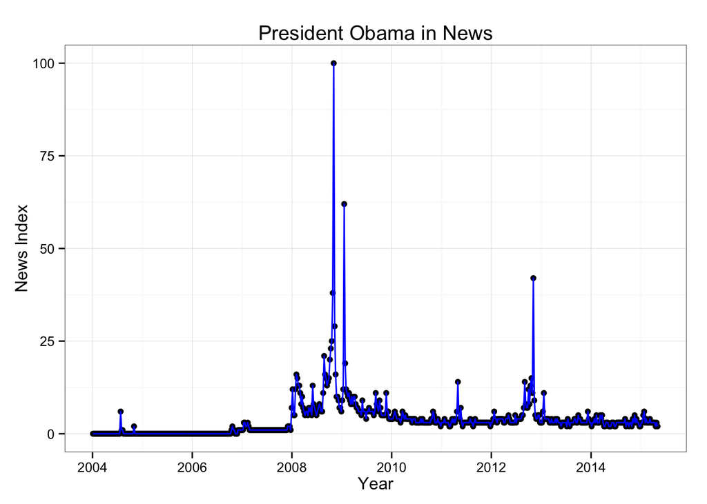

It is interesting to note the 2012 news interest on Mr.Obama is much lesser than 2008.

##### Interest across the globe.

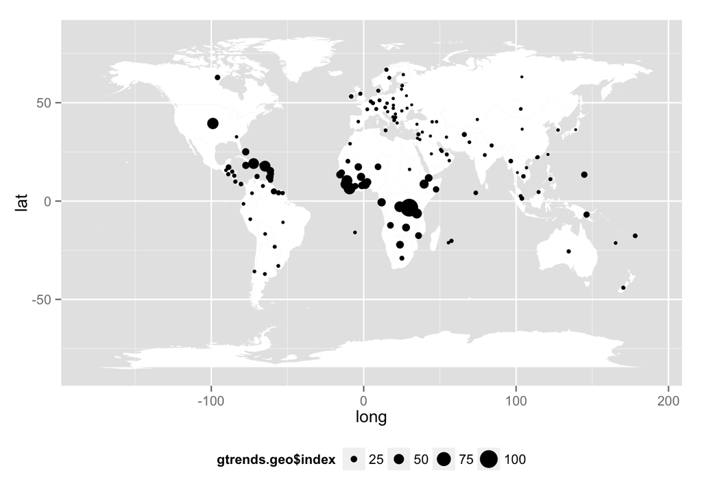

It is interesting to note that interest in President Obama is disproportionately higher in Africa and Caribbean.

#### Top 2012 campaign donors :

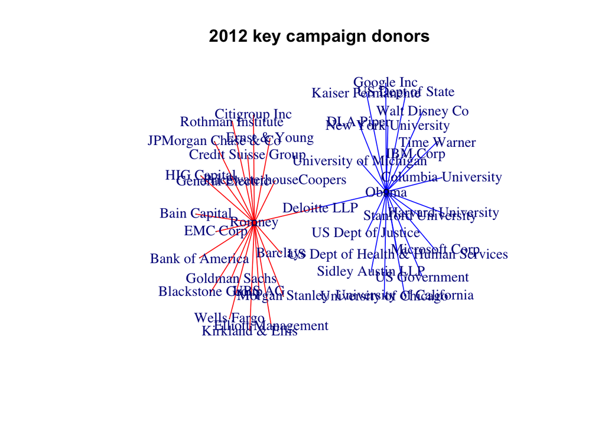

Key donors to Mr.Obama’s campaign seems to be spread across many groups such as universities , media companies, government employees and tech majors. Interestingly , majority of the donors to the republican challenger seems to be from the financial industry. Deloitte is the only top donor who contributed to both the campaigns while others seem to have picked their sides.

#### 2010-15 SOTU bi-grams heat-map:

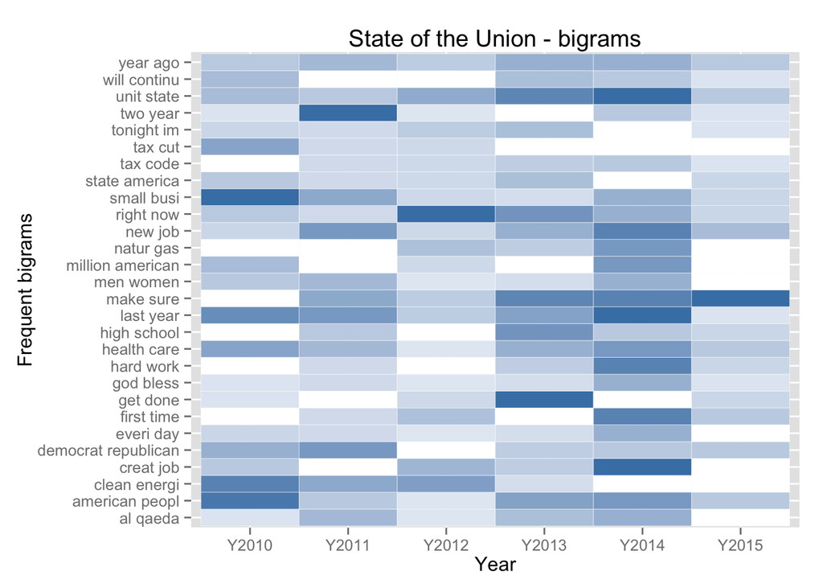

**Key Observations**

- The President has mentioned clean energy during the early years of his presidency which seems to have come down over the years.
- Natural gas is appearing more frequently in the recent years , coinciding with the increase in American gas production.

#### Obama Twitter Analysis:

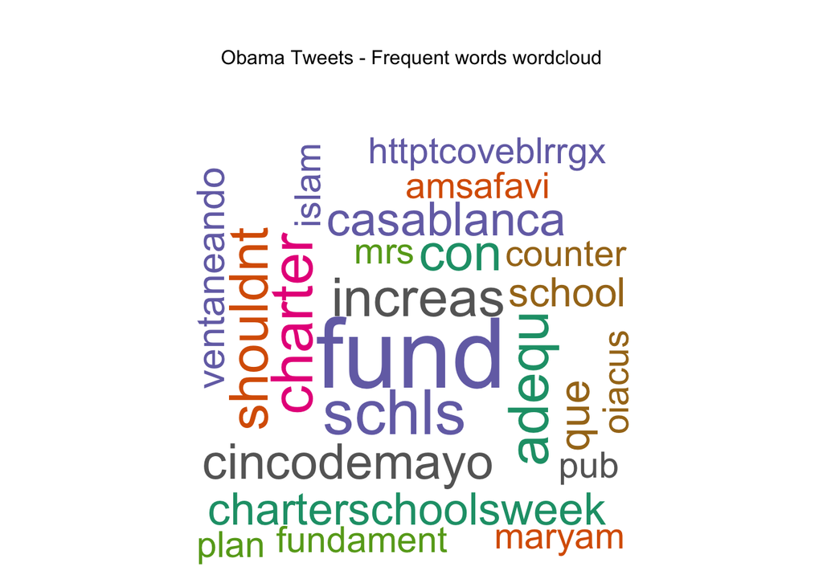

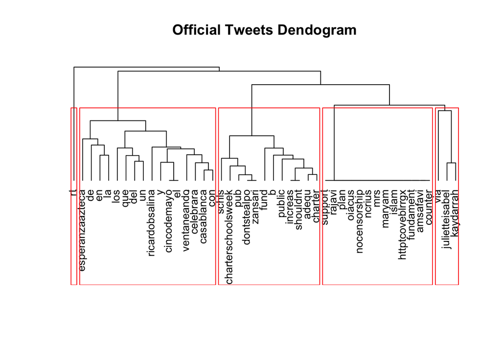

There seems to be three key clusters of tweets over the last 7 days.

- Charter schools and funding related tweets.
- Spanish tweets.
- maryam rajavi Islam related tweets.

Let us check the sentiment of the tweets using simple word sentiment methodology.

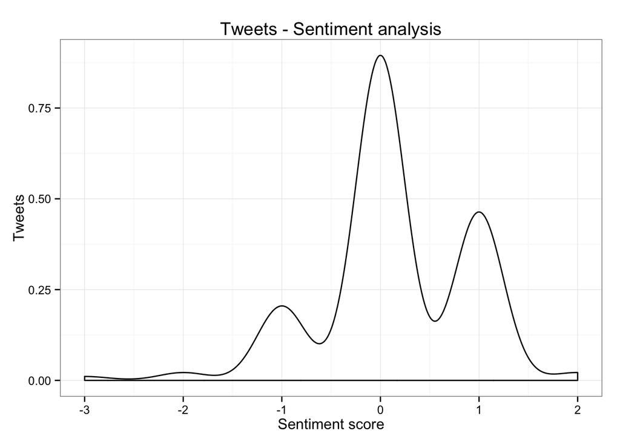

It seems the tweets have a slightly positive sentiment overall.

**Note:**

The tweets used for analysis are restricted to those with reference to official twitter handle @BarakObama , there are a few other unofficial handles referring to president Obama that might present a different sentiment score.

#### Conclusion:

I would have loved to analyse associations and social connections of the president using Facebook, but unfortunately Facebook friends details of the president is not available to access.  
However, we have uncovered quite a few interesting facts using a quick analysis of available public / social information about President Obama.